# TedTalk

## Exploratory Data Analysis with TED data

### What is EDA?

EDA stands for Exploratory Data Analysis. This analysis is essential to understand a given dataset. Usually to perform an EDA ,**we are asking**:

- What shape does the dataset have?
- How does the data look like?
- How many records?
- How many columns?
- What is the dataset about?
- What columns represent?
- What are the types for each column?

Once we understand the format, we can continue to **business questions about the dataset**:

- Is there any question given to answer over this dataset?
- What information can this dataset provide that is crucial to business?
- What dataset transformations will give us such information/answers?

**Iterate over:**

- Once an answer is given: what other questions can be asked?
- What visualization will help understand the dataset/answer this question?

-Once the visualization is rendered, what is surprising about the result?

- Did the visualization answer our question?
- Did the visualization bring anything new? What can be inferred?

Kaggle site (datasets) https://www.kaggle.com/datasets Recommended to practice EDA and others Competitions, Models,Discussions, etc

### Credit to the original creator

Credit to @justmarkham https://github.com/justmarkham/pycon-2019-tutorial/blob/master/environment.yml

I wanted to recreate the jupyter notebook step by step and make it public as a learning exercise, also adding insight on some points

Dataset https://github.com/justmarkham/pycon-2019-tutorial

Pycon session reference https://www.youtube.com/watch?v=dPwLlJkSHLo

## Retrieving the dataset to work with it

This one is a dataset containing info on several Ted Talks. Pandas has built-in features to produce plots that we will be using throughout this notebook.

```python
import pandas as pd
import matplotlib.pyplot as plt
%matplotlib inline
ted = pd.read_csv('ted.csv')
```

Using pandas features to plot number of comments on the ted dataset. The ted.comments part makes reference to the column "comments" on the "ted" dataframe.

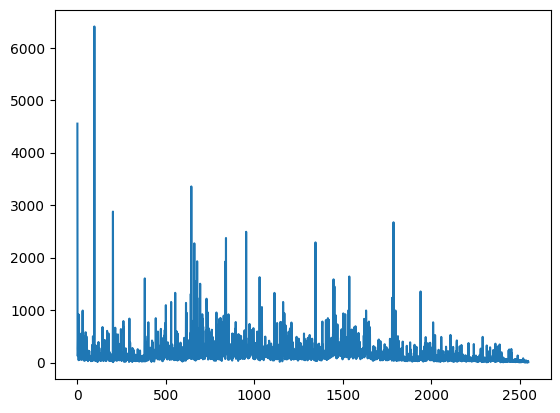

```python
ted.comments.plot()
```

## Pandas version set up

```python
pd.__version__
```

```
'2.0.1'
```

## TED talks dataset shape analysis

```python
ted = pd.read_csv('ted.csv')
```

```python
ted
```

|  | comments | description | duration | event | film_date | languages | main_speaker | name | num_speaker | published_date | ratings | related_talks | speaker_occupation | tags | title | url | views |
| --- | --- | --- | --- | --- | --- | --- | --- | --- | --- | --- | --- | --- | --- | --- | --- | --- | --- |
| 0 | 4553 | Sir Ken Robinson makes an entertaining and pro... | 1164 | TED2006 | 1140825600 | 60 | Ken Robinson | Ken Robinson: Do schools kill creativity? | 1 | 1151367060 | [{'id': 7, 'name': 'Funny', 'count': 19645}, {... | [{'id': 865, 'hero': 'https://pe.tedcdn.com/im... | Author/educator | ['children', 'creativity', 'culture', 'dance',... | Do schools kill creativity? | https://www.ted.com/talks/ken_robinson_says_sc... | 47227110 |
| 1 | 265 | With the same humor and humanity he exuded in ... | 977 | TED2006 | 1140825600 | 43 | Al Gore | Al Gore: Averting the climate crisis | 1 | 1151367060 | [{'id': 7, 'name': 'Funny', 'count': 544}, {'i... | [{'id': 243, 'hero': 'https://pe.tedcdn.com/im... | Climate advocate | ['alternative energy', 'cars', 'climate change... | Averting the climate crisis | https://www.ted.com/talks/al_gore_on_averting_... | 3200520 |
| 2 | 124 | New York Times columnist David Pogue takes aim... | 1286 | TED2006 | 1140739200 | 26 | David Pogue | David Pogue: Simplicity sells | 1 | 1151367060 | [{'id': 7, 'name': 'Funny', 'count': 964}, {'i... | [{'id': 1725, 'hero': 'https://pe.tedcdn.com/i... | Technology columnist | ['computers', 'entertainment', 'interface desi... | Simplicity sells | https://www.ted.com/talks/david_pogue_says_sim... | 1636292 |
| 3 | 200 | In an emotionally charged talk, MacArthur-winn... | 1116 | TED2006 | 1140912000 | 35 | Majora Carter | Majora Carter: Greening the ghetto | 1 | 1151367060 | [{'id': 3, 'name': 'Courageous', 'count': 760}... | [{'id': 1041, 'hero': 'https://pe.tedcdn.com/i... | Activist for environmental justice | ['MacArthur grant', 'activism', 'business', 'c... | Greening the ghetto | https://www.ted.com/talks/majora_carter_s_tale... | 1697550 |
| 4 | 593 | You've never seen data presented like this. Wi... | 1190 | TED2006 | 1140566400 | 48 | Hans Rosling | Hans Rosling: The best stats you've ever seen | 1 | 1151440680 | [{'id': 9, 'name': 'Ingenious', 'count': 3202}... | [{'id': 2056, 'hero': 'https://pe.tedcdn.com/i... | Global health expert; data visionary | ['Africa', 'Asia', 'Google', 'demo', 'economic... | The best stats you've ever seen | https://www.ted.com/talks/hans_rosling_shows_t... | 12005869 |
| ... | ... | ... | ... | ... | ... | ... | ... | ... | ... | ... | ... | ... | ... | ... | ... | ... | ... |
| 2545 | 17 | Between 2008 and 2016, the United States depor... | 476 | TED2017 | 1496707200 | 4 | Duarte Geraldino | Duarte Geraldino: What we're missing in the de... | 1 | 1505851216 | [{'id': 3, 'name': 'Courageous', 'count': 24},... | [{'id': 2596, 'hero': 'https://pe.tedcdn.com/i... | Journalist | ['TED Residency', 'United States', 'community'... | What we're missing in the debate about immigra... | https://www.ted.com/talks/duarte_geraldino_wha... | 450430 |
| 2546 | 6 | How can you study Mars without a spaceship? He... | 290 | TED2017 | 1492992000 | 3 | Armando Azua-Bustos | Armando Azua-Bustos: The most Martian place on... | 1 | 1505919737 | [{'id': 22, 'name': 'Fascinating', 'count': 32... | [{'id': 2491, 'hero': 'https://pe.tedcdn.com/i... | Astrobiologist | ['Mars', 'South America', 'TED Fellows', 'astr... | The most Martian place on Earth | https://www.ted.com/talks/armando_azua_bustos_... | 417470 |
| 2547 | 10 | Science fiction visions of the future show us ... | 651 | TED2017 | 1492992000 | 1 | Radhika Nagpal | Radhika Nagpal: What intelligent machines can ... | 1 | 1506006095 | [{'id': 1, 'name': 'Beautiful', 'count': 14}, ... | [{'id': 2346, 'hero': 'https://pe.tedcdn.com/i... | Robotics engineer | ['AI', 'ants', 'fish', 'future', 'innovation',... | What intelligent machines can learn from a sch... | https://www.ted.com/talks/radhika_nagpal_what_... | 375647 |
| 2548 | 32 | In an unmissable talk about race and politics ... | 1100 | TEDxMileHigh | 1499472000 | 1 | Theo E.J. Wilson | Theo E.J. Wilson: A black man goes undercover ... | 1 | 1506024042 | [{'id': 11, 'name': 'Longwinded', 'count': 3},... | [{'id': 2512, 'hero': 'https://pe.tedcdn.com/i... | Public intellectual | ['Internet', 'TEDx', 'United States', 'communi... | A black man goes undercover in the alt-right | https://www.ted.com/talks/theo_e_j_wilson_a_bl... | 419309 |
| 2549 | 8 | With more than half of the world population li... | 519 | TED2017 | 1492992000 | 1 | Karoliina Korppoo | Karoliina Korppoo: How a video game might help... | 1 | 1506092422 | [{'id': 21, 'name': 'Unconvincing', 'count': 2... | [{'id': 2682, 'hero': 'https://pe.tedcdn.com/i... | Game designer | ['cities', 'design', 'future', 'infrastructure... | How a video game might help us build better ci... | https://www.ted.com/talks/karoliina_korppoo_ho... | 391721 |

2550 rows × 17 columns

```python
ted.head()
```

|  | comments | description | duration | event | film_date | languages | main_speaker | name | num_speaker | published_date | ratings | related_talks | speaker_occupation | tags | title | url | views |
| --- | --- | --- | --- | --- | --- | --- | --- | --- | --- | --- | --- | --- | --- | --- | --- | --- | --- |
| 0 | 4553 | Sir Ken Robinson makes an entertaining and pro... | 1164 | TED2006 | 1140825600 | 60 | Ken Robinson | Ken Robinson: Do schools kill creativity? | 1 | 1151367060 | [{'id': 7, 'name': 'Funny', 'count': 19645}, {... | [{'id': 865, 'hero': 'https://pe.tedcdn.com/im... | Author/educator | ['children', 'creativity', 'culture', 'dance',... | Do schools kill creativity? | https://www.ted.com/talks/ken_robinson_says_sc... | 47227110 |
| 1 | 265 | With the same humor and humanity he exuded in ... | 977 | TED2006 | 1140825600 | 43 | Al Gore | Al Gore: Averting the climate crisis | 1 | 1151367060 | [{'id': 7, 'name': 'Funny', 'count': 544}, {'i... | [{'id': 243, 'hero': 'https://pe.tedcdn.com/im... | Climate advocate | ['alternative energy', 'cars', 'climate change... | Averting the climate crisis | https://www.ted.com/talks/al_gore_on_averting_... | 3200520 |
| 2 | 124 | New York Times columnist David Pogue takes aim... | 1286 | TED2006 | 1140739200 | 26 | David Pogue | David Pogue: Simplicity sells | 1 | 1151367060 | [{'id': 7, 'name': 'Funny', 'count': 964}, {'i... | [{'id': 1725, 'hero': 'https://pe.tedcdn.com/i... | Technology columnist | ['computers', 'entertainment', 'interface desi... | Simplicity sells | https://www.ted.com/talks/david_pogue_says_sim... | 1636292 |
| 3 | 200 | In an emotionally charged talk, MacArthur-winn... | 1116 | TED2006 | 1140912000 | 35 | Majora Carter | Majora Carter: Greening the ghetto | 1 | 1151367060 | [{'id': 3, 'name': 'Courageous', 'count': 760}... | [{'id': 1041, 'hero': 'https://pe.tedcdn.com/i... | Activist for environmental justice | ['MacArthur grant', 'activism', 'business', 'c... | Greening the ghetto | https://www.ted.com/talks/majora_carter_s_tale... | 1697550 |
| 4 | 593 | You've never seen data presented like this. Wi... | 1190 | TED2006 | 1140566400 | 48 | Hans Rosling | Hans Rosling: The best stats you've ever seen | 1 | 1151440680 | [{'id': 9, 'name': 'Ingenious', 'count': 3202}... | [{'id': 2056, 'hero': 'https://pe.tedcdn.com/i... | Global health expert; data visionary | ['Africa', 'Asia', 'Google', 'demo', 'economic... | The best stats you've ever seen | https://www.ted.com/talks/hans_rosling_shows_t... | 12005869 |

```python
ted.shape
```

```
(2550, 17)
```

```python
ted.dtypes
```

```
comments               int64
description           object
duration               int64
event                 object
film_date              int64
languages              int64
main_speaker          object
name                  object
num_speaker            int64
published_date         int64
ratings               object
related_talks         object
speaker_occupation    object
tags                  object
title                 object
url                   object
views                  int64
dtype: object
```

## Object columns can hold also dictionaries, lists and structures too ( additionally for strings)

1. What part of this dataset contains useful info? Tell me the sum of NA records on the dataset

```python
ted.isna().sum()
```

```
comments              0
description           0
duration              0
event                 0
film_date             0
languages             0
main_speaker          0
name                  0
num_speaker           0
published_date        0
ratings               0
related_talks         0
speaker_occupation    6
tags                  0
title                 0
url                   0
views                 0
dtype: int64
```

## Which talks provoke the most online discussion?

In this case we start with a business question: "*What are the talks that are more provokative ( produce the most online discussion)*? So creating a new column that can tell the amount of comments related to the number of views. We are interested in talks that generate the max number of comments per view.

```python
ted['comments_per_view'] = ted.comments / ted.views
```

```python
ted.sort_values('comments_per_view').tail()
```

|  | comments | description | duration | event | film_date | languages | main_speaker | name | num_speaker | published_date | ratings | related_talks | speaker_occupation | tags | title | url | views | comments_per_view |
| --- | --- | --- | --- | --- | --- | --- | --- | --- | --- | --- | --- | --- | --- | --- | --- | --- | --- | --- |
| 954 | 2492 | Janet Echelman found her true voice as an arti... | 566 | TED2011 | 1299110400 | 35 | Janet Echelman | Janet Echelman: Taking imagination seriously | 1 | 1307489760 | [{'id': 23, 'name': 'Jaw-dropping', 'count': 3... | [{'id': 453, 'hero': 'https://pe.tedcdn.com/im... | Artist | ['art', 'cities', 'culture', 'data', 'design',... | Taking imagination seriously | https://www.ted.com/talks/janet_echelman | 1832930 | 0.001360 |
| 694 | 1502 | Filmmaker Sharmeen Obaid-Chinoy takes on a ter... | 489 | TED2010 | 1265760000 | 32 | Sharmeen Obaid-Chinoy | Sharmeen Obaid-Chinoy: Inside a school for sui... | 1 | 1274865960 | [{'id': 23, 'name': 'Jaw-dropping', 'count': 3... | [{'id': 171, 'hero': 'https://pe.tedcdn.com/im... | Filmmaker | ['TED Fellows', 'children', 'culture', 'film',... | Inside a school for suicide bombers | https://www.ted.com/talks/sharmeen_obaid_chino... | 1057238 | 0.001421 |
| 96 | 6404 | Richard Dawkins urges all atheists to openly s... | 1750 | TED2002 | 1012608000 | 42 | Richard Dawkins | Richard Dawkins: Militant atheism | 1 | 1176689220 | [{'id': 3, 'name': 'Courageous', 'count': 3236... | [{'id': 86, 'hero': 'https://pe.tedcdn.com/ima... | Evolutionary biologist | ['God', 'atheism', 'culture', 'religion', 'sci... | Militant atheism | https://www.ted.com/talks/richard_dawkins_on_m... | 4374792 | 0.001464 |
| 803 | 834 | David Bismark demos a new system for voting th... | 422 | TEDGlobal 2010 | 1279065600 | 36 | David Bismark | David Bismark: E-voting without fraud | 1 | 1288685640 | [{'id': 25, 'name': 'OK', 'count': 111}, {'id'... | [{'id': 803, 'hero': 'https://pe.tedcdn.com/im... | Voting system designer | ['culture', 'democracy', 'design', 'global iss... | E-voting without fraud | https://www.ted.com/talks/david_bismark_e_voti... | 543551 | 0.001534 |
| 744 | 649 | Hours before New York lawmakers rejected a key... | 453 | New York State Senate | 1259712000 | 0 | Diane J. Savino | Diane J. Savino: The case for same-sex marriage | 1 | 1282062180 | [{'id': 25, 'name': 'OK', 'count': 100}, {'id'... | [{'id': 217, 'hero': 'https://pe.tedcdn.com/im... | Senator | ['God', 'LGBT', 'culture', 'government', 'law'... | The case for same-sex marriage | https://www.ted.com/talks/diane_j_savino_the_c... | 292395 | 0.002220 |

Views per comment to make it more interpretable

```python
ted.sort_values('comments_per_view').head()
```

|  | comments | description | duration | event | film_date | languages | main_speaker | name | num_speaker | published_date | ratings | related_talks | speaker_occupation | tags | title | url | views | comments_per_view |
| --- | --- | --- | --- | --- | --- | --- | --- | --- | --- | --- | --- | --- | --- | --- | --- | --- | --- | --- |
| 2534 | 2 | What the astronauts felt when they saw Earth f... | 725 | TEDxSkoll | 1491523200 | 1 | Benjamin Grant | Benjamin Grant: What it feels like to see Eart... | 1 | 1504814438 | [{'id': 10, 'name': 'Inspiring', 'count': 46},... | [{'id': 2511, 'hero': 'https://pe.tedcdn.com/i... | Author | ['TEDx', 'art', 'climate change', 'environment... | What it feels like to see Earth from space | https://www.ted.com/talks/benjamin_grant_what_... | 646174 | 0.000003 |
| 2501 | 3 | Meet Françoise Mouly, The New Yorker's art dir... | 509 | TEDNYC | 1488931200 | 12 | Françoise Mouly | Françoise Mouly: The stories behind The New Yo... | 1 | 1501770244 | [{'id': 7, 'name': 'Funny', 'count': 10}, {'id... | [{'id': 2479, 'hero': 'https://pe.tedcdn.com/i... | Art editor | ['TEDNYC', 'art', 'creativity', 'culture', 'de... | The stories behind The New Yorker's iconic covers | https://www.ted.com/talks/francoise_mouly_the_... | 839040 | 0.000004 |
| 2542 | 3 | In the century-old statues that occupy Cape To... | 795 | TEDGlobal 2017 | 1503792000 | 1 | Sethembile Msezane | Sethembile Msezane: Living sculptures that sta... | 1 | 1505488093 | [{'id': 1, 'name': 'Beautiful', 'count': 41}, ... | [{'id': 2873, 'hero': 'https://pe.tedcdn.com/i... | Artist | ['Africa', 'activism', 'art', 'community', 'hi... | Living sculptures that stand for history's truths | https://www.ted.com/talks/sethembile_msezane_l... | 542088 | 0.000006 |
| 2528 | 3 | Digital archaeologist Chance Coughenour is usi... | 717 | TEDxHamburg | 1465344000 | 5 | Chance Coughenour | Chance Coughenour: How your pictures can help ... | 1 | 1504209631 | [{'id': 9, 'name': 'Ingenious', 'count': 16}, ... | [{'id': 2673, 'hero': 'https://pe.tedcdn.com/i... | Digital archaeologist | ['TEDx', 'ancient world', 'archaeology', 'cons... | How your pictures can help reclaim lost history | https://www.ted.com/talks/chance_coughenour_ho... | 539207 | 0.000006 |
| 2494 | 7 | Jimmy Lin is developing technologies to catch ... | 730 | TED2017 | 1492992000 | 10 | Jimmy Lin | Jimmy Lin: A simple new blood test that can ca... | 1 | 1500994384 | [{'id': 1, 'name': 'Beautiful', 'count': 7}, {... | [{'id': 2498, 'hero': 'https://pe.tedcdn.com/i... | Geneticist | ['DNA', 'TED Fellows', 'biology', 'cancer', 'd... | A simple new blood test that can catch cancer ... | https://www.ted.com/talks/jimmy_lin_a_simple_n... | 1005506 | 0.000007 |

```python
ted['views_per_comment'] = ted.views/ted.comments
```

```python
ted.sort_values('views_per_comment')
```

|  | comments | description | duration | event | film_date | languages | main_speaker | name | num_speaker | published_date | ratings | related_talks | speaker_occupation | tags | title | url | views | comments_per_view | views_per_comment |
| --- | --- | --- | --- | --- | --- | --- | --- | --- | --- | --- | --- | --- | --- | --- | --- | --- | --- | --- | --- |
| 744 | 649 | Hours before New York lawmakers rejected a key... | 453 | New York State Senate | 1259712000 | 0 | Diane J. Savino | Diane J. Savino: The case for same-sex marriage | 1 | 1282062180 | [{'id': 25, 'name': 'OK', 'count': 100}, {'id'... | [{'id': 217, 'hero': 'https://pe.tedcdn.com/im... | Senator | ['God', 'LGBT', 'culture', 'government', 'law'... | The case for same-sex marriage | https://www.ted.com/talks/diane_j_savino_the_c... | 292395 | 0.002220 | 450.531587 |
| 803 | 834 | David Bismark demos a new system for voting th... | 422 | TEDGlobal 2010 | 1279065600 | 36 | David Bismark | David Bismark: E-voting without fraud | 1 | 1288685640 | [{'id': 25, 'name': 'OK', 'count': 111}, {'id'... | [{'id': 803, 'hero': 'https://pe.tedcdn.com/im... | Voting system designer | ['culture', 'democracy', 'design', 'global iss... | E-voting without fraud | https://www.ted.com/talks/david_bismark_e_voti... | 543551 | 0.001534 | 651.739808 |
| 96 | 6404 | Richard Dawkins urges all atheists to openly s... | 1750 | TED2002 | 1012608000 | 42 | Richard Dawkins | Richard Dawkins: Militant atheism | 1 | 1176689220 | [{'id': 3, 'name': 'Courageous', 'count': 3236... | [{'id': 86, 'hero': 'https://pe.tedcdn.com/ima... | Evolutionary biologist | ['God', 'atheism', 'culture', 'religion', 'sci... | Militant atheism | https://www.ted.com/talks/richard_dawkins_on_m... | 4374792 | 0.001464 | 683.134291 |
| 694 | 1502 | Filmmaker Sharmeen Obaid-Chinoy takes on a ter... | 489 | TED2010 | 1265760000 | 32 | Sharmeen Obaid-Chinoy | Sharmeen Obaid-Chinoy: Inside a school for sui... | 1 | 1274865960 | [{'id': 23, 'name': 'Jaw-dropping', 'count': 3... | [{'id': 171, 'hero': 'https://pe.tedcdn.com/im... | Filmmaker | ['TED Fellows', 'children', 'culture', 'film',... | Inside a school for suicide bombers | https://www.ted.com/talks/sharmeen_obaid_chino... | 1057238 | 0.001421 | 703.886818 |
| 954 | 2492 | Janet Echelman found her true voice as an arti... | 566 | TED2011 | 1299110400 | 35 | Janet Echelman | Janet Echelman: Taking imagination seriously | 1 | 1307489760 | [{'id': 23, 'name': 'Jaw-dropping', 'count': 3... | [{'id': 453, 'hero': 'https://pe.tedcdn.com/im... | Artist | ['art', 'cities', 'culture', 'data', 'design',... | Taking imagination seriously | https://www.ted.com/talks/janet_echelman | 1832930 | 0.001360 | 735.525682 |
| ... | ... | ... | ... | ... | ... | ... | ... | ... | ... | ... | ... | ... | ... | ... | ... | ... | ... | ... | ... |
| 2494 | 7 | Jimmy Lin is developing technologies to catch ... | 730 | TED2017 | 1492992000 | 10 | Jimmy Lin | Jimmy Lin: A simple new blood test that can ca... | 1 | 1500994384 | [{'id': 1, 'name': 'Beautiful', 'count': 7}, {... | [{'id': 2498, 'hero': 'https://pe.tedcdn.com/i... | Geneticist | ['DNA', 'TED Fellows', 'biology', 'cancer', 'd... | A simple new blood test that can catch cancer ... | https://www.ted.com/talks/jimmy_lin_a_simple_n... | 1005506 | 0.000007 | 143643.714286 |
| 2528 | 3 | Digital archaeologist Chance Coughenour is usi... | 717 | TEDxHamburg | 1465344000 | 5 | Chance Coughenour | Chance Coughenour: How your pictures can help ... | 1 | 1504209631 | [{'id': 9, 'name': 'Ingenious', 'count': 16}, ... | [{'id': 2673, 'hero': 'https://pe.tedcdn.com/i... | Digital archaeologist | ['TEDx', 'ancient world', 'archaeology', 'cons... | How your pictures can help reclaim lost history | https://www.ted.com/talks/chance_coughenour_ho... | 539207 | 0.000006 | 179735.666667 |
| 2542 | 3 | In the century-old statues that occupy Cape To... | 795 | TEDGlobal 2017 | 1503792000 | 1 | Sethembile Msezane | Sethembile Msezane: Living sculptures that sta... | 1 | 1505488093 | [{'id': 1, 'name': 'Beautiful', 'count': 41}, ... | [{'id': 2873, 'hero': 'https://pe.tedcdn.com/i... | Artist | ['Africa', 'activism', 'art', 'community', 'hi... | Living sculptures that stand for history's truths | https://www.ted.com/talks/sethembile_msezane_l... | 542088 | 0.000006 | 180696.000000 |
| 2501 | 3 | Meet Françoise Mouly, The New Yorker's art dir... | 509 | TEDNYC | 1488931200 | 12 | Françoise Mouly | Françoise Mouly: The stories behind The New Yo... | 1 | 1501770244 | [{'id': 7, 'name': 'Funny', 'count': 10}, {'id... | [{'id': 2479, 'hero': 'https://pe.tedcdn.com/i... | Art editor | ['TEDNYC', 'art', 'creativity', 'culture', 'de... | The stories behind The New Yorker's iconic covers | https://www.ted.com/talks/francoise_mouly_the_... | 839040 | 0.000004 | 279680.000000 |
| 2534 | 2 | What the astronauts felt when they saw Earth f... | 725 | TEDxSkoll | 1491523200 | 1 | Benjamin Grant | Benjamin Grant: What it feels like to see Eart... | 1 | 1504814438 | [{'id': 10, 'name': 'Inspiring', 'count': 46},... | [{'id': 2511, 'hero': 'https://pe.tedcdn.com/i... | Author | ['TEDx', 'art', 'climate change', 'environment... | What it feels like to see Earth from space | https://www.ted.com/talks/benjamin_grant_what_... | 646174 | 0.000003 | 323087.000000 |

2550 rows × 19 columns

Checking in graphical way the comments distribution. Line plot is the first choice ( but no the best one) X= index Y= value of the comment

This graph doesn't have a time component, line plot is not adequate.

This plot is good, however it doesn't provide detail that we can use. We just see that there are more TED talks that have between 0-1000 comments. We need more detail to make sure this intuition is true.

## Visualization of the comment distribution

A histogram plot is more adequate for frequency distribution

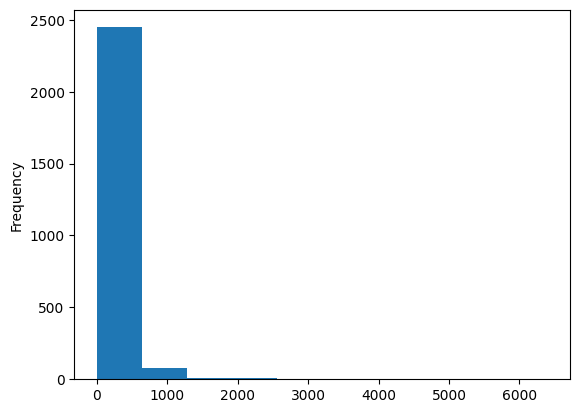

```python
ted.comments.plot(kind='hist')
```

Vast majority is on the left of 1000, so we would need to filter to understand more

So what does this look like in detail. Let's filter the dataframe by the ones that have less than 1000

```python
ted[ted.comments>=1000].shape
```

```
(32, 19)
```

By removing the ted talks with more than 1000 comments we cut out information that is not relevant to the question asked. Just 32 records!

This is the distribution of the ted talks within the ones with less than 1000 comments

```python
ted[ted.comments<1000].comments.plot(kind='hist')
```

[output not shown]

Same result using query:

```python
ted.query('comments<1000 ').comments.plot(kind='hist')
```

[output not shown]

Same result but using loc:

```python
ted.loc[ ted.comments<1000,'comments' ].plot(kind='hist')
```

[output not shown]

## Plot the number of talks that took place each year

```python
ted.dtypes
```

```
comments                int64
description            object
duration                int64
event                  object
film_date               int64
languages               int64
main_speaker           object
name                   object
num_speaker             int64
published_date          int64
ratings                object
related_talks          object
speaker_occupation     object
tags                   object
title                  object
url                    object
views                   int64
comments_per_view     float64
views_per_comment     float64
dtype: object
```

```python
ted
```

|  | comments | description | duration | event | film_date | languages | main_speaker | name | num_speaker | published_date | ratings | related_talks | speaker_occupation | tags | title | url | views | comments_per_view | views_per_comment |
| --- | --- | --- | --- | --- | --- | --- | --- | --- | --- | --- | --- | --- | --- | --- | --- | --- | --- | --- | --- |
| 0 | 4553 | Sir Ken Robinson makes an entertaining and pro... | 1164 | TED2006 | 1140825600 | 60 | Ken Robinson | Ken Robinson: Do schools kill creativity? | 1 | 1151367060 | [{'id': 7, 'name': 'Funny', 'count': 19645}, {... | [{'id': 865, 'hero': 'https://pe.tedcdn.com/im... | Author/educator | ['children', 'creativity', 'culture', 'dance',... | Do schools kill creativity? | https://www.ted.com/talks/ken_robinson_says_sc... | 47227110 | 0.000096 | 10372.745443 |
| 1 | 265 | With the same humor and humanity he exuded in ... | 977 | TED2006 | 1140825600 | 43 | Al Gore | Al Gore: Averting the climate crisis | 1 | 1151367060 | [{'id': 7, 'name': 'Funny', 'count': 544}, {'i... | [{'id': 243, 'hero': 'https://pe.tedcdn.com/im... | Climate advocate | ['alternative energy', 'cars', 'climate change... | Averting the climate crisis | https://www.ted.com/talks/al_gore_on_averting_... | 3200520 | 0.000083 | 12077.433962 |
| 2 | 124 | New York Times columnist David Pogue takes aim... | 1286 | TED2006 | 1140739200 | 26 | David Pogue | David Pogue: Simplicity sells | 1 | 1151367060 | [{'id': 7, 'name': 'Funny', 'count': 964}, {'i... | [{'id': 1725, 'hero': 'https://pe.tedcdn.com/i... | Technology columnist | ['computers', 'entertainment', 'interface desi... | Simplicity sells | https://www.ted.com/talks/david_pogue_says_sim... | 1636292 | 0.000076 | 13195.903226 |
| 3 | 200 | In an emotionally charged talk, MacArthur-winn... | 1116 | TED2006 | 1140912000 | 35 | Majora Carter | Majora Carter: Greening the ghetto | 1 | 1151367060 | [{'id': 3, 'name': 'Courageous', 'count': 760}... | [{'id': 1041, 'hero': 'https://pe.tedcdn.com/i... | Activist for environmental justice | ['MacArthur grant', 'activism', 'business', 'c... | Greening the ghetto | https://www.ted.com/talks/majora_carter_s_tale... | 1697550 | 0.000118 | 8487.750000 |
| 4 | 593 | You've never seen data presented like this. Wi... | 1190 | TED2006 | 1140566400 | 48 | Hans Rosling | Hans Rosling: The best stats you've ever seen | 1 | 1151440680 | [{'id': 9, 'name': 'Ingenious', 'count': 3202}... | [{'id': 2056, 'hero': 'https://pe.tedcdn.com/i... | Global health expert; data visionary | ['Africa', 'Asia', 'Google', 'demo', 'economic... | The best stats you've ever seen | https://www.ted.com/talks/hans_rosling_shows_t... | 12005869 | 0.000049 | 20245.984823 |
| ... | ... | ... | ... | ... | ... | ... | ... | ... | ... | ... | ... | ... | ... | ... | ... | ... | ... | ... | ... |
| 2545 | 17 | Between 2008 and 2016, the United States depor... | 476 | TED2017 | 1496707200 | 4 | Duarte Geraldino | Duarte Geraldino: What we're missing in the de... | 1 | 1505851216 | [{'id': 3, 'name': 'Courageous', 'count': 24},... | [{'id': 2596, 'hero': 'https://pe.tedcdn.com/i... | Journalist | ['TED Residency', 'United States', 'community'... | What we're missing in the debate about immigra... | https://www.ted.com/talks/duarte_geraldino_wha... | 450430 | 0.000038 | 26495.882353 |
| 2546 | 6 | How can you study Mars without a spaceship? He... | 290 | TED2017 | 1492992000 | 3 | Armando Azua-Bustos | Armando Azua-Bustos: The most Martian place on... | 1 | 1505919737 | [{'id': 22, 'name': 'Fascinating', 'count': 32... | [{'id': 2491, 'hero': 'https://pe.tedcdn.com/i... | Astrobiologist | ['Mars', 'South America', 'TED Fellows', 'astr... | The most Martian place on Earth | https://www.ted.com/talks/armando_azua_bustos_... | 417470 | 0.000014 | 69578.333333 |
| 2547 | 10 | Science fiction visions of the future show us ... | 651 | TED2017 | 1492992000 | 1 | Radhika Nagpal | Radhika Nagpal: What intelligent machines can ... | 1 | 1506006095 | [{'id': 1, 'name': 'Beautiful', 'count': 14}, ... | [{'id': 2346, 'hero': 'https://pe.tedcdn.com/i... | Robotics engineer | ['AI', 'ants', 'fish', 'future', 'innovation',... | What intelligent machines can learn from a sch... | https://www.ted.com/talks/radhika_nagpal_what_... | 375647 | 0.000027 | 37564.700000 |
| 2548 | 32 | In an unmissable talk about race and politics ... | 1100 | TEDxMileHigh | 1499472000 | 1 | Theo E.J. Wilson | Theo E.J. Wilson: A black man goes undercover ... | 1 | 1506024042 | [{'id': 11, 'name': 'Longwinded', 'count': 3},... | [{'id': 2512, 'hero': 'https://pe.tedcdn.com/i... | Public intellectual | ['Internet', 'TEDx', 'United States', 'communi... | A black man goes undercover in the alt-right | https://www.ted.com/talks/theo_e_j_wilson_a_bl... | 419309 | 0.000076 | 13103.406250 |
| 2549 | 8 | With more than half of the world population li... | 519 | TED2017 | 1492992000 | 1 | Karoliina Korppoo | Karoliina Korppoo: How a video game might help... | 1 | 1506092422 | [{'id': 21, 'name': 'Unconvincing', 'count': 2... | [{'id': 2682, 'hero': 'https://pe.tedcdn.com/i... | Game designer | ['cities', 'design', 'future', 'infrastructure... | How a video game might help us build better ci... | https://www.ted.com/talks/karoliina_korppoo_ho... | 391721 | 0.000020 | 48965.125000 |

2550 rows × 19 columns

## Displaying by column

```python
ted.published_date
```

```
0       1151367060
1       1151367060
2       1151367060
3       1151367060
4       1151440680
           ...
2545    1505851216
2546    1505919737
2547    1506006095
2548    1506024042
2549    1506092422
Name: published_date, Length: 2550, dtype: int64
```

1. Showing a sample of 30 elements of the column "event" to check if it contains the year

```python
ted.event.sample(30)
```

```
493                     TED2009
1556             TEDGlobal 2013
929                 TEDxCaltech
292                     TED2002
1150             TEDGlobal 2011
2126       TEDxAmoskeagMillyard
768                  TED@Cannes
752         Mission Blue Voyage
307                     TED2006
510              TEDGlobal 2009
2435             TEDxSanQuentin
819                 TEDxMidwest
2105              TEDWomen 2015
84                      TED2005
129              TEDGlobal 2007
```

[output cut: 16 more lines]

Unfortunately the date is not in date format, but as a timestamp, we require converting to date.

```python
ted.film_date
```

```
0       1140825600
1       1140825600
2       1140739200
3       1140912000
4       1140566400
           ...
2545    1496707200
2546    1492992000
2547    1492992000
2548    1499472000
2549    1492992000
Name: film_date, Length: 2550, dtype: int64
```

## Using datetime transformations

```python
pd.to_datetime(ted.published_date)
```

```
0      1970-01-01 00:00:01.151367060
1      1970-01-01 00:00:01.151367060
2      1970-01-01 00:00:01.151367060
3      1970-01-01 00:00:01.151367060
4      1970-01-01 00:00:01.151440680
                    ...
2545   1970-01-01 00:00:01.505851216
2546   1970-01-01 00:00:01.505919737
2547   1970-01-01 00:00:01.506006095
2548   1970-01-01 00:00:01.506024042
2549   1970-01-01 00:00:01.506092422
Name: published_date, Length: 2550, dtype: datetime64[ns]
```

```python
pd.to_datetime(ted.published_date, unit='s')
```

```
0      2006-06-27 00:11:00
1      2006-06-27 00:11:00
2      2006-06-27 00:11:00
3      2006-06-27 00:11:00
4      2006-06-27 20:38:00
               ...
2545   2017-09-19 20:00:16
2546   2017-09-20 15:02:17
2547   2017-09-21 15:01:35
2548   2017-09-21 20:00:42
2549   2017-09-22 15:00:22
Name: published_date, Length: 2550, dtype: datetime64[ns]
```

The unit parameter is crucial for the conversion to be correct.

```python
ted['film_datetime']= pd.to_datetime(ted.published_date, unit='s')
```

Reviewing that the data makes sense comparing with event name

```python
ted.film_datetime
```

```
0      2006-06-27 00:11:00
1      2006-06-27 00:11:00
2      2006-06-27 00:11:00
3      2006-06-27 00:11:00
4      2006-06-27 20:38:00
               ...
2545   2017-09-19 20:00:16
2546   2017-09-20 15:02:17
2547   2017-09-21 15:01:35
2548   2017-09-21 20:00:42
2549   2017-09-22 15:00:22
Name: film_datetime, Length: 2550, dtype: datetime64[ns]
```

```python
ted[['event','film_datetime']].sample(25)
```

|  | event | film_datetime |
| --- | --- | --- |
| 1693 | TED Fellows Retreat 2013 | 2014-03-06 16:01:23 |
| 1985 | TED2015 | 2015-05-28 15:21:08 |
| 1136 | TEDxCanberra | 2012-02-07 16:08:24 |
| 283 | TED2008 | 2008-09-02 01:00:00 |
| 1784 | TEDGlobal 2013 | 2014-07-09 14:51:35 |
| 94 | TED2003 | 2007-04-14 21:40:00 |
| 1551 | TEDxCERN | 2013-07-22 15:12:18 |
| 1314 | TEDxHousesOfParliament | 2012-08-12 15:13:23 |
| 250 | TED2008 | 2008-06-30 10:52:00 |
| 2122 | TEDWomen 2015 | 2016-01-21 15:49:36 |
| 2246 | TEDSummit | 2016-07-13 15:00:19 |
| 2182 | TED2015 | 2016-04-12 14:41:40 |
| 2036 | TEDGlobal 2014 | 2015-08-31 14:57:59 |
| 697 | TEDxNYED | 2010-05-31 11:13:00 |
| 529 | TEDxUSC | 2009-10-06 01:00:00 |
| 1994 | TED2015 | 2015-06-11 15:37:45 |
| 2044 | TED2015 | 2015-09-14 15:32:00 |
| 943 | TED2011 | 2011-05-24 14:54:00 |
| 1471 | TED2013 | 2013-04-04 14:56:21 |
| 2178 | TED2016 | 2016-04-07 15:03:12 |
| 1623 | TEDCity2.0 | 2013-11-13 15:59:49 |
| 2155 | TEDGlobal>Geneva | 2016-03-08 16:05:54 |
| 2543 | TED2017 | 2017-09-18 15:14:47 |
| 2506 | TEDxMileHigh | 2017-08-10 14:37:43 |
| 2113 | TEDxMarin | 2016-01-07 16:40:18 |

```python
ted.dtypes
```

```
comments                       int64
description                   object
duration                       int64
event                         object
film_date                      int64
languages                      int64
main_speaker                  object
name                          object
num_speaker                    int64
published_date                 int64
ratings                       object
related_talks                 object
speaker_occupation            object
tags                          object
title                         object
url                           object
views                          int64
comments_per_view            float64
views_per_comment            float64
film_datetime         datetime64[ns]
dtype: object
```

film_datetime has datetime64[ns] . This allows us to use a namespace "dt" with Pandas. For example:

```python
ted.film_datetime.dt.year
```

```
0       2006
1       2006
2       2006
3       2006
4       2006
        ...
2545    2017
2546    2017
2547    2017
2548    2017
2549    2017
Name: film_datetime, Length: 2550, dtype: int32
```

From that point on, we can use agregations like "value_counts()". Below a sentence that can bring the year and the number of values that contain that year on the dataset.

```python
ted.film_datetime.dt.year.value_counts()
```

```
film_datetime
2012    306
2011    261
2010    257
2013    244
2016    243
2014    240
2009    222
2015    220
2017    197
2008    188
2007    122
2006     50
Name: count, dtype: int64
```

We can build a plot just calling it at the end of the sentence.

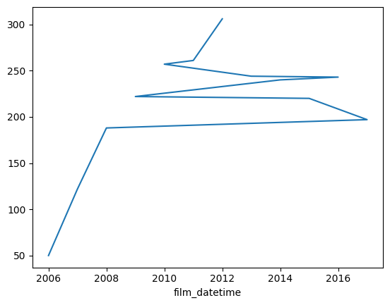

```python
ted.film_datetime.dt.year.value_counts().plot()
```

What can be concluded from the plot?

Not much since the data is not ordered. Pandas will show them by default in the order in which they appear.

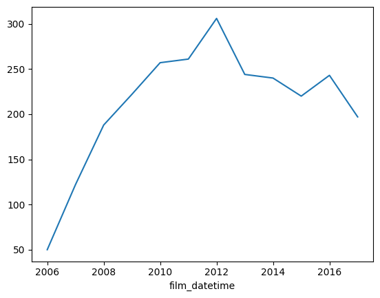

```python
ted.film_datetime.dt.year.value_counts().sort_index().plot()
```

It makes more sense.

```python
ted.film_datetime.dt.day_of_year
```

```
0       178
1       178
2       178
3       178
4       178
       ...
2545    262
2546    263
2547    264
2548    264
2549    265
Name: film_datetime, Length: 2550, dtype: int32
```

Other namespaces by the type of the column

```python
ted.event.str.lower()
```

```
0            ted2006
1            ted2006
2            ted2006
3            ted2006
4            ted2006
            ...
2545         ted2017
2546         ted2017
2547         ted2017
2548    tedxmilehigh
2549         ted2017
Name: event, Length: 2550, dtype: object
```

Is the number of talks in steep decline?

```python
ted[ted.film_datetime.dt.year =='2017'].value_counts()
```

```
Series([], Name: count, dtype: int64)
```

```python
ted[ted.film_datetime.dt.year==2017].film_datetime.dt.year.value_counts()
```

```
film_datetime
2017    197
Name: count, dtype: int64
```

```python
ted[ted.film_datetime.dt.year==2016].film_datetime.dt.year.value_counts()
```

```
film_datetime
2016    243
Name: count, dtype: int64
```

Are TED talks on steep decline on 2017? No, maybe the dataset is missing data from 2017 an onwards.

**Sometimes it is convenient to removing data from the dataset so the conclusions are relevant**

## What were the "best" events in TED history to attend?

# Exercise 1.

1. How can we measure event/talk quality?

Let's use number of views for a talk as a measure of quality. The event with the greatest number of views in its talks is the best event.

**We have to consider that an event is a aggregation of talks.**

## Using aggregations with Pandas

- groupby over a column
- For each category you can call an aggregate function ( 'mean' in this case)
- You can later sort by value or sort by index

The code shown below means to sort the events which talks have the least amount of views (mean).

```python
ted.groupby('event').views.mean().sort_values().head()
```

```
event
The Do Lectures           112321.0
TEDxIslay                 120274.0
TEDxWaterloo              138812.0
AORN Congress             149818.0
TEDxNASA@SiliconValley    155895.0
Name: views, dtype: float64
```

The code shown below means to sort the events which talks have the highest amount views (mean).

1. Group by event

2.For each event 3.Aggregation = mean 4.Column = views

```python
ted.groupby('event').views.mean().sort_values().tail()
```

```
event
TEDxNorrkoping        6569493.0
TEDxCreativeCoast     8444981.0
TEDxBloomington       9484259.5
TEDxHouston          16140250.5
TEDxPuget Sound      34309432.0
Name: views, dtype: float64
```

However we would like to detail more: maybe an event had a few successful talks

TEDExPugetSound looks like a great event, but let's break it down to see the talks per event. We need to group by two columns:

1. We need 2 different aggregations

## Using multiple aggregation functions

```python
ted.groupby('event').views.agg(['count','mean']).sort_values('mean').tail()
```

| event | count | mean |
| --- | --- | --- |
| TEDxNorrkoping | 1 | 6569493.0 |
| TEDxCreativeCoast | 1 | 8444981.0 |
| TEDxBloomington | 2 | 9484259.5 |
| TEDxHouston | 2 | 16140250.5 |
| TEDxPuget Sound | 1 | 34309432.0 |

We see TEDxPuget Sound had just one talk (or at least one that was published), and maybe that one was a really good one.

Adding 'sum' to the agg functions, to see **what events had the most total number of views**

```python
ted.groupby('event').views.agg(['count','mean','sum']).sort_values('sum').tail()
```

| event | count | mean | sum |
| --- | --- | --- | --- |
| TED2006 | 45 | 3.274345e+06 | 147345533 |
| TED2015 | 75 | 2.011017e+06 | 150826305 |
| TEDGlobal 2013 | 66 | 2.584163e+06 | 170554736 |
| TED2014 | 84 | 2.072874e+06 | 174121423 |
| TED2013 | 77 | 2.302700e+06 | 177307937 |

## Conclusions

1. Think about how to use data creatively
2. Think about the disavantages of your approach.
3. Using small sample sizes

## Unpack ratings data

Ratings data is in a stringified json format, so it needs "unpacking" in a way that we can work with this data.

```python
ted.ratings.head()
```

```
0    [{'id': 7, 'name': 'Funny', 'count': 19645}, {...
1    [{'id': 7, 'name': 'Funny', 'count': 544}, {'i...
2    [{'id': 7, 'name': 'Funny', 'count': 964}, {'i...
3    [{'id': 3, 'name': 'Courageous', 'count': 760}...
4    [{'id': 9, 'name': 'Ingenious', 'count': 3202}...
Name: ratings, dtype: object
```

## Evaluate a string in a given object format and return as the object it is formatted like

```python
import ast
```

This library can be used to describe a stringified list and retrieve it as a list object

```python
ast.literal_eval('[1,2,3]')
```

```
[1, 2, 3]
```

```python
ted.ratings
```

```
0       [{'id': 7, 'name': 'Funny', 'count': 19645}, {...
1       [{'id': 7, 'name': 'Funny', 'count': 544}, {'i...
2       [{'id': 7, 'name': 'Funny', 'count': 964}, {'i...
3       [{'id': 3, 'name': 'Courageous', 'count': 760}...
4       [{'id': 9, 'name': 'Ingenious', 'count': 3202}...
                              ...
2545    [{'id': 3, 'name': 'Courageous', 'count': 24},...
2546    [{'id': 22, 'name': 'Fascinating', 'count': 32...
2547    [{'id': 1, 'name': 'Beautiful', 'count': 14}, ...
2548    [{'id': 11, 'name': 'Longwinded', 'count': 3},...
2549    [{'id': 21, 'name': 'Unconvincing', 'count': 2...
Name: ratings, Length: 2550, dtype: object
```

```python
type(ted.ratings)
```

```
pandas.core.series.Series
```

```python
type(ted.ratings[0])
```

```
str
```

```python
ast.literal_eval(ted.ratings[0])
```

```
[{'id': 7, 'name': 'Funny', 'count': 19645},
 {'id': 1, 'name': 'Beautiful', 'count': 4573},
 {'id': 9, 'name': 'Ingenious', 'count': 6073},
 {'id': 3, 'name': 'Courageous', 'count': 3253},
 {'id': 11, 'name': 'Longwinded', 'count': 387},
 {'id': 2, 'name': 'Confusing', 'count': 242},
 {'id': 8, 'name': 'Informative', 'count': 7346},
 {'id': 22, 'name': 'Fascinating', 'count': 10581},
 {'id': 21, 'name': 'Unconvincing', 'count': 300},
 {'id': 24, 'name': 'Persuasive', 'count': 10704},
 {'id': 23, 'name': 'Jaw-dropping', 'count': 4439},
 {'id': 25, 'name': 'OK', 'count': 1174},
 {'id': 26, 'name': 'Obnoxious', 'count': 209},
 {'id': 10, 'name': 'Inspiring', 'count': 24924}]
```

```python
type(ast.literal_eval(ted.ratings[0]))
```

```
list
```

Creating a function to encapsulate this

```python
def  str_to_list(ratings_list):
    return ast.literal_eval(ratings_list)
```

So that we can apply this function to this field on the dataframe

```python
ted ['ratings_list']=ted.ratings.apply( lambda x: ast.literal_eval(x))
```

```python
ted.ratings_list
```

```
0       [{'id': 7, 'name': 'Funny', 'count': 19645}, {...
1       [{'id': 7, 'name': 'Funny', 'count': 544}, {'i...
2       [{'id': 7, 'name': 'Funny', 'count': 964}, {'i...
3       [{'id': 3, 'name': 'Courageous', 'count': 760}...
4       [{'id': 9, 'name': 'Ingenious', 'count': 3202}...
                              ...
2545    [{'id': 3, 'name': 'Courageous', 'count': 24},...
2546    [{'id': 22, 'name': 'Fascinating', 'count': 32...
2547    [{'id': 1, 'name': 'Beautiful', 'count': 14}, ...
2548    [{'id': 11, 'name': 'Longwinded', 'count': 3},...
2549    [{'id': 21, 'name': 'Unconvincing', 'count': 2...
Name: ratings_list, Length: 2550, dtype: object
```

```python
type(ted.ratings_list)
```

```
pandas.core.series.Series
```

```python
type(ted.ratings_list[0])
```

```
list
```

## Map vs apply

1. Map seems to have a subset of apply

2.Use apply anytime it's necessary 3. Don't use apply when there is a built-in function that can do the same: usually built-in pandas functions are more reliable , performant, documented and tested. 4. Map is a better wrap for performance. However you don't always care about performance and sometimes they are equivalent (like for a small number of values). 5.Use apply last, rather than fast. 6. Apply is confusing because:

- There is a series apply method
- There is a dataframe apply method
- There is a series map method
- There is a dataframe applymap method

Use it with care!

We added a column that is a series of lists, cotaining the ratings for the talks ( instead of series of stringified lists)

## Count the number of ratings received by each talk and store it in a column called num_ratings

1. For each talk, calculate the percentage of ratings that were negative
2. For each talk, calculate the average number of ratings it received per day since it was published.

```python
ted.ratings_list[1]
```

```
[{'id': 7, 'name': 'Funny', 'count': 544},
 {'id': 3, 'name': 'Courageous', 'count': 139},
 {'id': 2, 'name': 'Confusing', 'count': 62},
 {'id': 1, 'name': 'Beautiful', 'count': 58},
 {'id': 21, 'name': 'Unconvincing', 'count': 258},
 {'id': 11, 'name': 'Longwinded', 'count': 113},
 {'id': 8, 'name': 'Informative', 'count': 443},
 {'id': 10, 'name': 'Inspiring', 'count': 413},
 {'id': 22, 'name': 'Fascinating', 'count': 132},
 {'id': 9, 'name': 'Ingenious', 'count': 56},
 {'id': 24, 'name': 'Persuasive', 'count': 268},
 {'id': 23, 'name': 'Jaw-dropping', 'count': 116},
 {'id': 26, 'name': 'Obnoxious', 'count': 131},
 {'id': 25, 'name': 'OK', 'count': 203}]
```

```python
def get_num_ratings(list_of_dicts):
    num = 0
    for d in list_of_dicts:
        num = num + d['count']
    return num
```

```python
get_num_ratings(ted.ratings_list[1])
```

```
2936
```

```python
ted['num_ratings'] = ted.ratings_list.apply(get_num_ratings)
```

```python
ted.num_ratings
```

```
0       93850
1        2936
2        2824
3        3728
4       25620
        ...
2545      192
2546      151
2547      136
2548      583
2549      142
Name: num_ratings, Length: 2550, dtype: int64
```

```python
ted.num_ratings.describe()
```

```
count     2550.000000
mean      2436.408235
std       4226.795631
min         68.000000
25%        870.750000
50%       1452.500000
75%       2506.750000
max      93850.000000
Name: num_ratings, dtype: float64
```

Another way to do this ( Using lambdas in one go!)

```python
pd.DataFrame(ted.ratings_list[0])['count'].sum()
```

```
93850
```

```python
ted['another_num_ratings'] = ted.ratings_list.apply( lambda x: pd.DataFrame(x)['count'].sum())
```

```python
ted.another_num_ratings
```

```
0       93850
1        2936
2        2824
3        3728
4       25620
        ...
2545      192
2546      151
2547      136
2548      583
2549      142
Name: another_num_ratings, Length: 2550, dtype: int64
```

```python
ted.another_num_ratings.describe()
```

```
count     2550.000000
mean      2436.408235
std       4226.795631
min         68.000000
25%        870.750000
50%       1452.500000
75%       2506.750000
max      93850.000000
Name: another_num_ratings, dtype: float64
```

## Conclusions

1. Write one-liners as much as you can and check your work as you go
2. Lambda is best for simple functions

## Which occupations deliver the funniest TED talks on average?

## Step 1: Count the number of funny ratings

```python
ted.ratings_list.head()
```

```
0    [{'id': 7, 'name': 'Funny', 'count': 19645}, {...
1    [{'id': 7, 'name': 'Funny', 'count': 544}, {'i...
2    [{'id': 7, 'name': 'Funny', 'count': 964}, {'i...
3    [{'id': 3, 'name': 'Courageous', 'count': 760}...
4    [{'id': 9, 'name': 'Ingenious', 'count': 3202}...
Name: ratings_list, dtype: object
```

1. Does every rating contain a "Funny" score?

```python
ted.ratings.str.contains('Funny').value_counts()
```

```
ratings
True    2550
Name: count, dtype: int64
```

```python
def get_funny_ratings(list_of_dicts):
    for d in list_of_dicts:
        if d['name']=='Funny':
            return d['count']
```

```python
ted['funny_ratings'] = ted.ratings_list.apply(get_funny_ratings)
```

```python
ted.funny_ratings
```

```
0       19645
1         544
2         964
3          59
4        1390
        ...
2545        1
2546       20
2547        1
2548       63
2549        0
Name: funny_ratings, Length: 2550, dtype: int64
```

```python
ted.funny_ratings.describe()
```

```
count     2550.000000
mean       154.468627
std        589.137728
min          0.000000
25%          8.000000
50%         21.000000
75%         92.000000
max      19645.000000
Name: funny_ratings, dtype: float64
```

```python
ted['funny_rate'] = ted.funny_ratings / ted.num_ratings
```

```python
ted.funny_rate
```

```
0       0.209323
1       0.185286
2       0.341360
3       0.015826
4       0.054254
          ...
2545    0.005208
2546    0.132450
2547    0.007353
2548    0.108062
2549    0.000000
Name: funny_rate, Length: 2550, dtype: float64
```

```python
ted.funny_rate.describe()
```

```
count    2550.000000
mean        0.050361
std         0.087779
min         0.000000
25%         0.005922
50%         0.014981
75%         0.047736
max         0.702076
Name: funny_rate, dtype: float64
```

How to verify that this measure makes sense? Sorting about the "Funny" rating for each talk in the listings would make sense.

```python
ted.sort_values('funny_rate').speaker_occupation.tail(20)
```

```
1849                       Science humorist
337                                Comedian
124     Performance poet, multimedia artist
315                                  Expert
1168             Social energy entrepreneur
1468                          Ornithologist
595                  Comedian, voice artist
1534                         Cartoon editor
97                                 Satirist
2297                          Actor, writer
568                                Comedian
675                          Data scientist
21                     Humorist, web artist
194                                Jugglers
2273                    Comedian and writer
2114                    Comedian and writer
173                                Investor
747                                Comedian
1398                               Comedian
685             Actor, comedian, playwright
Name: speaker_occupation, dtype: object
```

```python
ted.sort_values('funny_rate').speaker_occupation.head(20)
```

```
2549               Game designer
1612                   Biologist
612                     Sculptor
998               Penguin expert
593                     Engineer
284               Space activist
1041         Biomedical engineer
1618      Spinal cord researcher
2132    Computational geneticist
442                     Sculptor
426              Author, thinker
458                     Educator
2437      Environmental engineer
1491             Photojournalist
1893     Forensic anthropologist
783             Marine biologist
195                    Kenyan MP
772             HIV/AIDS fighter
788            Building activist
936                Neuroengineer
Name: speaker_occupation, dtype: object
```

## Step 3: Analyze the funny rate by occupation

Using group by , used by speaker would give us the funny rate by occupation

```python
ted.groupby('speaker_occupation').funny_rate.mean().sort_values().tail(20)
```

```
speaker_occupation
Cartoonist                       0.369335
YouTube trends manager           0.404886
Entrepreneur, Lego enthusiast    0.409814
First aid instructor             0.413043
Expert                           0.415295
Philosopher-comic                0.415871
Marketing expert                 0.434353
Pranksters                       0.437240
African grey parrot              0.441525
Comedian + Designer              0.463068
Science humorist                 0.468405
Social energy entrepreneur       0.502117
Comedian, voice artist           0.503542
Cartoon editor                   0.511628
Satirist                         0.512383
Comedian                         0.512457
Actor, writer                    0.515152
Actor, comedian, playwright      0.558107
Jugglers                         0.566828
Comedian and writer              0.602085
Name: funny_rate, dtype: float64
```

```python
ted.speaker_occupation.describe()
```

```
count       2544
unique      1458
top       Writer
freq          45
Name: speaker_occupation, dtype: object
```

The problem with this calculation is that these occupations have a small sample size. 1458 are unique values, so there is a lot of occupations that are unique

## Focus on occupations that are well-represented in the data

1. Generate a list of the most represented occupations

```python
occupation_counts = ted.speaker_occupation.value_counts()
```

```python
top_occupations = occupation_counts [occupation_counts>= 5].index
```

```python
top_occupations
```

```
Index(['Writer', 'Artist', 'Designer', 'Journalist', 'Entrepreneur',
       'Architect', 'Inventor', 'Psychologist', 'Photographer', 'Filmmaker',
       'Economist', 'Author', 'Neuroscientist', 'Educator', 'Roboticist',
       'Philosopher', 'Biologist', 'Physicist', 'Musician', 'Marine biologist',
       'Activist', 'Global health expert; data visionary', 'Technologist',
       'Graphic designer', 'Historian', 'Philanthropist', 'Astronomer',
       'Behavioral economist', 'Oceanographer', 'Singer/songwriter', 'Poet',
       'Futurist', 'Engineer', 'Computer scientist', 'Social psychologist',
       'Novelist', 'Mathematician', 'Astrophysicist', 'Social entrepreneur',
       'Photojournalist', 'Writer, activist', 'Evolutionary biologist',
       'Legal activist', 'Climate advocate', 'Techno-illusionist',
       'Singer-songwriter', 'Comedian', 'Performance poet, multimedia artist',
       'Reporter', 'Paleontologist', 'Chemist', 'Cartoonist',
       'Investor and advocate for moral leadership', 'Violinist',
       'Tech visionary', 'Producer', 'Sound consultant', 'Game designer',
       'Physician', 'Surgeon', 'Sculptor', 'Researcher', 'Science writer',
       'Data scientist', 'Musician, activist', 'Social Media Theorist',
       'Environmentalist, futurist', 'Chef'],
      dtype='object', name='speaker_occupation')
```

```python
type(top_occupations)
```

```
pandas.core.indexes.base.Index
```

```python
ted_top_occupations = ted[ted['speaker_occupation'].isin(top_occupations)]
```

```python
ted_top_occupations.shape
```

```
(786, 25)
```

```python
ted_top_occupations.describe()
```

|  | comments | duration | film_date | languages | num_speaker | published_date | views | comments_per_view | views_per_comment | film_datetime | num_ratings | another_num_ratings | funny_ratings | funny_rate |
| --- | --- | --- | --- | --- | --- | --- | --- | --- | --- | --- | --- | --- | --- | --- |
| count | 786.000000 | 786.000000 | 7.860000e+02 | 786.000000 | 786.000000 | 7.860000e+02 | 7.860000e+02 | 786.000000 | 786.000000 | 786 | 786.000000 | 786.000000 | 786.000000 | 786.000000 |
| mean | 205.409669 | 826.286260 | 1.301029e+09 | 27.815522 | 1.034351 | 1.326715e+09 | 1.712339e+06 | 0.000154 | 14206.494098 | 2012-01-16 11:49:37.044529152 | 2525.507634 | 2525.507634 | 165.482188 | 0.053808 |
| min | 2.000000 | 135.000000 | 4.265316e+08 | 0.000000 | 1.000000 | 1.151367e+09 | 5.044300e+04 | 0.000003 | 683.134291 | 2006-06-27 00:11:00 | 142.000000 | 142.000000 | 0.000000 | 0.000000 |
| 25% | 63.000000 | 541.500000 | 1.233965e+09 | 23.000000 | 1.000000 | 1.251356e+09 | 7.192218e+05 | 0.000059 | 5540.287089 | 2009-08-27 07:00:00 | 918.000000 | 918.000000 | 8.000000 | 0.006463 |
| 50% | 124.000000 | 848.000000 | 1.310558e+09 | 28.000000 | 1.000000 | 1.323102e+09 | 1.123634e+06 | 0.000106 | 9473.250007 | 2011-12-05 16:19:41 | 1490.000000 | 1490.000000 | 26.000000 | 0.017125 |
| 75% | 224.750000 | 1063.000000 | 1.394950e+09 | 34.000000 | 1.000000 | 1.401073e+09 | 1.759730e+06 | 0.000180 | 16808.135662 | 2014-05-26 02:54:11.500000 | 2640.000000 | 2640.000000 | 110.000000 | 0.055667 |
| max | 6404.000000 | 3955.000000 | 1.503792e+09 | 72.000000 | 4.000000 | 1.506092e+09 | 4.315540e+07 | 0.001464 | 323087.000000 | 2017-09-22 15:00:22 | 65968.000000 | 65968.000000 | 7315.000000 | 0.669927 |
| std | 339.003617 | 404.903481 | 1.274605e+08 | 10.260198 | 0.202130 | 9.433474e+07 | 2.509243e+06 | 0.000170 | 18131.368966 | NaN | 3904.029024 | 3904.029024 | 482.137463 | 0.089033 |

```python
ted_top_occupations.groupby('speaker_occupation').funny_rate.mean().sort_values().tail(20)
```

```
speaker_occupation
Science writer                          0.055993
Designer                                0.059287
Writer                                  0.060745
Game designer                           0.062317
Reporter                                0.066250
Evolutionary biologist                  0.069157
Novelist                                0.070876
Entrepreneur                            0.073295
Author                                  0.075508
Artist                                  0.078939
Global health expert; data visionary    0.090306
Poet                                    0.107398
Graphic designer                        0.135718
Techno-illusionist                      0.152171
Cartoonist                              0.162120
Data scientist                          0.184076
Producer                                0.202531
Singer/songwriter                       0.252205
Performance poet, multimedia artist     0.306468
Comedian                                0.512457
Name: funny_rate, dtype: float64
```

## Conclusions

1. Check your assumptions about your data
2. Check whether your results make sense.
3. Check the type of pandas operations: they are usually DataFrame or Series.
4. Watch out for small sample sizes.
5. Consider the impact of missing data: this is NOT showing any errors :)